# 基于Word2Vec+NMF模型美国民主党辩论笔录分析（自然语言处理教程系列一）

#### **本项目着眼于分析美国民主党的辩论笔录，探索使用主题模型来从统计数据中寻找议员更喜欢讨论的话题及其水平**

#### 先来说说分析的结果：**民主党12次的辩论内容，其主要议题围绕税收、医疗健康、政策、移民、气候问题、种族歧视等话题来进行，我们在本项目中还分析了每个议题中大家辩论的时候最关注的十个词**

#### PS：背景说明 三年前，我在工作中的很多会议、头脑风暴中负责记录文字内容，当时就在想，怎么样用程序分析出每个人的核心观点。虽然在五年前就使用过结巴分词，但是语义、词向量方面，自己还是个小白。就在那个时候，我开始接触并学习自然语言处理，一路晃来磕磕绊绊已经三年多时间了，现在想做一个系列的自然语言处理应用案例，计划主要完成五个小案例的内容

#### **1. 基于Word2Vec+NMF模型美国民主党辩论笔录分析**

#### **2. 基于搜索引擎用户搜索数据的用户画像分析**

#### **3. 对重大灾难事件的微博数据的挖掘分析**

#### **4. 基于nlp的音乐、商品、视频评论数据的分析**

#### **5. 基于nlp的垃圾邮件的检测与分类**

#### 附上中国新闻网对2月25日辩论的一篇报道 [民主党总统竞选人第十场辩论：围攻桑德斯](http://www.chinanews.com/gj/2020/02-26/9105287.shtml)

#### 首先导入进行数据探索、分析时最常用的numpy和pandas库，使用`os.walk`把目录下的文件打印出来，目录下笔录文件的位置在`/home/aistudio/debate_transcripts_v3_2020-02-26.csv`

```python
# Importing the essential libraries for the exercise.
import numpy as np # linear algebra
import pandas as pd # data processing, CSV file I/O (e.g. pd.read_csv)
import os

# Linking the directory to access the dataset.
for dirname, _, filenames in os.walk('/home/aistudio/data'):
    for filename in filenames:
        print(os.path.join(dirname, filename))
```

```
/home/aistudio/data/data23289/2020debate.zip
```

#### 也可以在公开数据集中找到[我提供的数据集位置](https://aistudio.baidu.com/aistudio/projectdetail/306102)，导入到自己的项目后使用`unzip`命令进行解压即可

```python
!unzip data/data23289/2020debate.zip
```

```
Archive:  data/data23289/2020debate.zip
replace debate_transcripts_v3_2020-02-26.csv? [y]es, [n]o, [A]ll, [N]one, [r]ename: ^C
```

#### 接着我们定义数据路径，使用`pd.read_csv`读取，编码方式是[`ISO-8859-1`编码](https://baike.baidu.com/item/ISO-8859-1/7878872?fr=aladdin#3/)

#### 我们使用head方法简单看一下数据源情况，包含了日期date，辩论名称debate_name，辩论环节debate_section，辩论人speaker，辩论内容speech及对应用时speaking_time_seconds

```python
# Reading the data, and exploring its characteristics.
path = "debate_transcripts_v3_2020-02-26.csv"
data = pd.read_csv(path, encoding = "ISO-8859-1")
data.head(5)
```

|  | date | debate_name | debate_section | speaker | speech | speaking_time_seconds |
| --- | --- | --- | --- | --- | --- | --- |
| 0 | 02-25-2020 | South Carolina Democratic Debate Transcript: F... | Part 1: South Carolina Democratic Debate Trans... | Norah ODonnell | Good evening and welcome, the Democratic presi... | 8.0 |
| 1 | 02-25-2020 | South Carolina Democratic Debate Transcript: F... | Part 1: South Carolina Democratic Debate Trans... | Gayle King | And Super Tuesday is just a week away and this... | 22.0 |
| 2 | 02-25-2020 | South Carolina Democratic Debate Transcript: F... | Part 1: South Carolina Democratic Debate Trans... | Norah ODonnell | And CBS News is proud to bring you this debate... | 14.0 |
| 3 | 02-25-2020 | South Carolina Democratic Debate Transcript: F... | Part 1: South Carolina Democratic Debate Trans... | Gayle King | And we are partnering tonight also with Twitte... | 10.0 |
| 4 | 02-25-2020 | South Carolina Democratic Debate Transcript: F... | Part 1: South Carolina Democratic Debate Trans... | Norah ODonnell | Now, here are the rules for the next two hours... | 31.0 |

```
debate_names = data["debate_name"] 取出了字段是debate_name的这一列数据
```

#### 接着使用`set`进行去重，再使用len方法计算元素数量。辩论环节,辩论议员数目也是用同样的方法进行获取

#### 最后使用`np.mean`方法，对辩论时长求平均秒数

```python
# Dictionary of the debates.
debate_names = data["debate_name"]
number_of_debates = len(set(debate_names))
print("Total number of democratic debates:", number_of_debates, "debates")

# Dictionary of number of sections.
debate_section = data["debate_section"]
number_of_sections = len(set(debate_section))
print("Maximum number of sections in the debates:", number_of_sections, "sections")

# Dictionary of name of speakers.
dem_speakers = data["speaker"]
number_of_speakers = len(set(dem_speakers))
print("Total number of democratic speakers:",number_of_speakers, "speakers")

# Mean duration of speech.
print("The average speaking time is:",np.mean(data["speaking_time_seconds"]), "seconds")
```

```
Total number of democratic debates: 12 debates
Maximum number of sections in the debates: 20 sections
Total number of democratic speakers: 106 speakers
The average speaking time is: 16.49230769230769 seconds
```

#### 对数据进行可视化前，先确定各个内容对应的数据量`debs[i] = debs.get(i, 0) + 1`，并以对应的数量为指标`key=lambda item: item[1]`进行升序排列

#### 用`debs.get(i, 0)`获取字典数据的好处是如果键值i不存在，就返回0，如果直接使用`debs[i]`，键值i不存在就会报错

```python
# Sorted dictionary of debates.
debs = dict()
for i in debate_names:
    debs[i] = debs.get(i, 0) + 1

debates = {k: v for k, v in sorted(debs.items(), key=lambda item: item[1])}
print(debates)
# Sorted dictionary of sections.
secs = dict()
for i in debate_section:
    secs[i] = secs.get(i, 0) + 1

sections = {k: v for k, v in sorted(secs.items(), key=lambda item: item[1])}
print(sections)
# Sorted dictionary of speakers.
spkrs = dict()
for i in dem_speakers:
    spkrs[i] = spkrs.get(i, 0) + 1

speakers = {k: v for k, v in sorted(spkrs.items(), key=lambda item: item[1])}
print(speakers)
```

```
{'New Hampshire Democratic Debate Transcript': 323, 'January Iowa Democratic Debate Transcript': 347, 'November Democratic Debate Transcript \x96 5th Debate Transcript from Atlanta': 362, 'December Democratic Debate Transcript: Sixth Debate from Los Angeles': 385, 'September Houston Democratic Debat…
{'Part 3: Closing Statements': 56, 'Closing Statements': 76, 'Part 4: Closing Statements': 101, 'Part 2: South Carolina Democratic Debate Transcript': 114, 'Part 2: Criminal Justice Reform, Climate Change': 129, 'Part 3: National Security, Foreign Policy, Impeachment': 140, 'Part 3: Trade Policy, Na…
{'Announcer': 1, 'Amy Walter': 1, 'A. Cooper': 1, 'Male': 1, 'Speaker 4': 1, 'Speaker 5': 1, 'Speaker 6': 1, 'Speaker 16': 1, 'Speaker 17': 1, 'Speaker 18': 1, 'Speaker 19': 1, 'Speaker 20': 1, 'Speaker 10': 1, 'Speaker 14': 1, 'Female': 2, 'Moderator 4': 2, 'N. Henderson': 2, 'Eric Stalwell': 2, 'S…
```

#### 接着进行绘图，我们这里就用条形图。下面是两个条形图的案例

#### 条形图的绘制方法是`plt.bar`，绘制直方图是`plt.hist`，绘制折线图是`plt.plot`，散点图是`plt.scatter(x,y)`，饼图是`plt.pie(data)`

```
<BarContainer object of 6 artists>
```

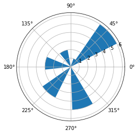

```python
%matplotlib inline
import numpy as np
import matplotlib.pyplot as plt
plt.axes(polar=True)
data1 = np.array([1,2,3,4,5,6])
index = [1,2,3,4,5,7]
plt.bar(x=index,height=data1,width=0.5)
```

```
<BarContainer object of 8 artists>
```

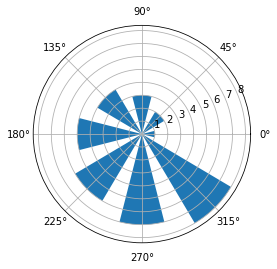

```python
index = np.arange(0,2*np.pi,np.pi/4)
data1 = [1,2,3,4,5,6,7,8]
plt.axes(polar=True)
plt.bar(x=index,height=data1,width=0.5)
```

#### 12场辩论的议题`list(debates.keys())`作为横坐标，纵坐标`debates.values()`是对应的就此内容进行辩论讲演的次数，绘制红色`color='red'`条形图。

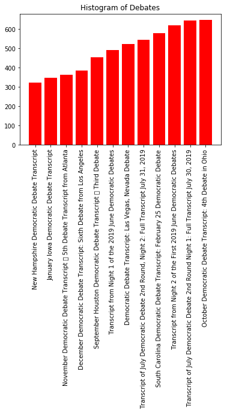

```python
# Plot of debates
%matplotlib inline
import matplotlib.pyplot as plt

plt.bar(list(debates.keys()), debates.values(), color='red')
plt.title("Histogram of Debates")
plt.xticks(rotation = 90)
plt.rcParams["figure.figsize"] = (5,10)
```

#### 从图表可以看出，这十二次辩论发言次数最多的是十月民主辩论，七月民主辩论次之，南卡罗来纳州民主党辩论笔录数量排在第四

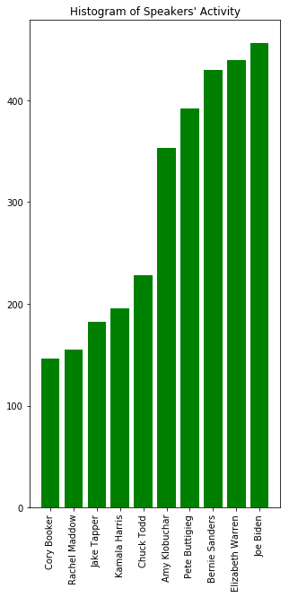

```python
# Plot of speakers' activity
plt.bar(list(speakers.keys())[-10:], list(speakers.values())[-10:], color='green')
plt.title("Histogram of Speakers' Activity")
plt.xticks(rotation=90)
#plt.tight_layout()
plt.rcParams["figure.figsize"] = (8.0,8)
```

#### 从图表中可以看出，辩论次数最多的是美国副总统拜登，然后是伊丽莎白·沃伦，现为美国民主党、马萨诸塞州参议员，美国政界自由派的重要代表人物之一，自由派“旗手”。

#### 排名第三的就是开篇介绍时中新网的报道中的主人公，伯尼·桑德斯，其参加了2020年总统竞选，这些天其在民主党初选中的迅速崛起，其和沃伦的竞争非常激烈

#### 接着介绍一下spaCy库和en_core_web_sm模型，spaCy和nltk，gensim一样，也是自然语言处理常用的一个库，spaCy带有预先训练的统计模型和单词向量，目前支持20多种语言的标记。

#### 它具有世界上速度最快的句法分析器，用于标签的卷积神经网络模型，解析和命名实体识别以及与深度学习整合。SpaCy的作者Matthew Honnibal也是nlp界的一个大牛。项目地址在github上explosion/spaCy#spacy-industrial-strength-nlp，从1.7.0版本开始，spaCy的模型可以作为Python包安装

#### 首先安装一下spaCy库和en_core_web_sm模型

```python
!pip install spacy
!pip install en_core_web_sm-2.2.5.tar.gz
```

#### 为了比较容易的定位出话题的主题词，我们只取出词性为名词的这些`token.lemma_ for token in doc if token.pos_ == "NOUN"`，把他们合并到一个列表中

```python
import spacy
import en_core_web_sm

nlp = en_core_web_sm.load(disable=['parser', 'ner'])
random_state = 0

# Taking into consideration only nouns so as to identify the topics.
def only_nouns(texts):
    output = []
    for doc in nlp.pipe(texts):
        noun_text = " ".join(token.lemma_ for token in doc if token.pos_ == 'NOUN')
        output.append(noun_text)
    return output
```

#### 接着把演讲中的名词作为最后一列合并到我们的数据集上，speech_nouns列的词就是speech中的名词

```python
# Merging the nouns-only list to the dataset.
data_new = only_nouns(data["speech"])
speech_nouns = pd.DataFrame(data_new)
data["Index"] = data.index
speech_nouns["Index"] = speech_nouns.index
democrat_data = pd.merge(data, speech_nouns, on="Index")
democrat_data.columns = ["index","debate_name", "debate_section", "speaker", "speech", "speaking_time_seconds", "index", "speech_nouns"]
democrat_data = democrat_data.drop(["index"], axis=1)
democrat_data.head()
```

|  | debate_name | debate_section | speaker | speech | speaking_time_seconds | speech_nouns |
| --- | --- | --- | --- | --- | --- | --- |
| 0 | South Carolina Democratic Debate Transcript: F... | Part 1: South Carolina Democratic Debate Trans... | Norah ODonnell | Good evening and welcome, the Democratic presi... | 8.0 | evening welcome primary primary day |
| 1 | South Carolina Democratic Debate Transcript: F... | Part 1: South Carolina Democratic Debate Trans... | Gayle King | And Super Tuesday is just a week away and this... | 22.0 | week day year voter state ballot mind debate t... |
| 2 | South Carolina Democratic Debate Transcript: F... | Part 1: South Carolina Democratic Debate Trans... | Norah ODonnell | And CBS News is proud to bring you this debate... | 14.0 | debate co - sponsor organization voter leader |
| 3 | South Carolina Democratic Debate Transcript: F... | Part 1: South Carolina Democratic Debate Trans... | Gayle King | And we are partnering tonight also with Twitte... | 10.0 | tonight home debate question candidate hashtag |
| 4 | South Carolina Democratic Debate Transcript: F... | Part 1: South Carolina Democratic Debate Trans... | Norah ODonnell | Now, here are the rules for the next two hours... | 31.0 | rule hour question minute second second follow... |

#### 接着使用NMF取出10个高频话题，先说说NMF，NMF作为一个漂亮的矩阵分解方法，它可以很好的用于主题模型,并且使主题的结果有基于概率分布的解释性。我们在接触自然语言领域都会涉及到基于监督学习与非监督学习的文本分类，在非监督学习领域会提到lsa、lda主题模型的实现。但之前的讨论都是基于工具层面的。其实这些模型的基础算法都是NMF模型分解。可以我们不会对文本从底层去实现这样的算法。但了解其实现的机制还是非常有帮助的。NMF的思想：V=WH（W权重矩阵、H特征矩阵、V原矩阵），通过计算从原矩阵提取权重和特征两个不同的矩阵出来。属于一个无监督学习的算法。

[figure not shown]

#### 在 scikit-learn中，NMF在sklearn.decomposition.NMF包中，它支持L1和L2的正则化，而W,H的求解使用坐标轴下降法来实现。

NMF需要注意的参数有：

1） `n_components`：即我们的主题数k, 选择k值需要一些对于要分析文本主题大概的先验知识。可以多选择几组k的值进行NMF，然后对结果人为的进行一些验证。

2） `init` : 用于帮我们选择W,H迭代初值的算法， 默认是None,即自动选择值，不使用选择初值的算法。如果我们对收敛速度不满意，才需要关注这个值，从`scikit-learn`提供的算法中选择一个合适的初值选取算法。

3）`alpha`: 正则化参数`α`,需要调参。开始建议选择一个比较小的值，如果发现效果不好在调参增大。

4）`l1_ratio`： 正则化参数`ρ,L1`正则化的比例，仅在α>0时有效，需要调参。开始建议不使用，即用默认值0, 如果对L2的正则化不满意再加上L1正则化。

从上面可见，使用NMF的关键参数在于主题数的选择n_components和正则化的两个超参数`α,ρ`。

此外，W矩阵一般在调用`fit_transform`方法的返回值里获得，而H矩阵则保存在NMF类的`components_`成员中。

```python
# Number of topics to extract
n_topics = 10

# Vectorization of the nouns.
from sklearn.feature_extraction.text import CountVectorizer, TfidfVectorizer
vec = TfidfVectorizer(max_features=5000, stop_words="english", max_df=0.95, min_df=2)
features = vec.fit_transform(democrat_data.speech_nouns)

# Non-negative matrix factorization.
from sklearn.decomposition import NMF
cls = NMF(n_components=n_topics, random_state=random_state)
cls.fit(features)
```

```
NMF(alpha=0.0, beta_loss='frobenius', init=None, l1_ratio=0.0, max_iter=200,
  n_components=10, random_state=0, shuffle=False, solver='cd', tol=0.0001,
  verbose=0)
```

#### 接着我们把每个话题下面最高频的20个词拿出来

```python
# List of unique words
feature_names = vec.get_feature_names()

# Number of top words per topic
n_top_words = 20

for i, topic_vec in enumerate(cls.components_):
    print(i, end=' ')
    for fid in topic_vec.argsort()[-1:-n_top_words-1:-1]:
        print(feature_names[fid], end=' ')
    print()
```

```
0 response congressman sir justice congresswoman buyback chance idea stage candidate discussion wealth colleague senator secretary state sponsor person guarantee tax
1 people lot law government election campaign healthcare justice drug party million help community reason country corporation prescription cost class life
2 second candidate closing floor statement followup minute sir rule clarification tonight breakdown day night line debate energy rebuttal moderator audience
3 time break candidate sir minute statement debate moment closing fact chance action point guy district lot matter campaign justice rule
4 crosstalk lot option minute thing chance let policy tonight campaign courage candidate beginning bait rule citizen respond moment allegation 00
5 question candidate debate tonight voter stage answer night minute break race right audience word campaign viewer lot topic economy moderator
6 president vice day impeachment law war stage office decision thing presidency candidate congressman situation justice moment history end experience order
7 country way thing year world fact job policy problem climate change woman child war family money tax school state stage
8 plan healthcare insurance health company option care cost family drug taxis employer class year coverage price premium industry dollar right
9 issue climate change gun moment voter violence community election lot candidate justice day race mic energy majority party threat gut
```

#### 接着安装gensim库，Gensim是一款开源的第三方Python工具包，用于从原始的非结构化的文本中，无监督地学习到文本隐层的主题向量表达。

```python
!pip install gensim
```

#### 接下来我们使用nltk和gensim，做出各辩论话题的相似度计算，首先使用nltk进行分词，下载nltk提供的`punkt`分词器及停用词，接着对数据进行分词

```python
import string
from nltk.tokenize import word_tokenize
from nltk.corpus import stopwords
import nltk
nltk.download('punkt')
nltk.download('stopwords')
democrat_speeches = list()
lines = data["speech"].tolist()

for line in lines:
    tokens = word_tokenize(line)
    # lowercase
    tokens = [word.lower() for word in tokens]
    # remove punctuation
    table = str.maketrans("","", string.punctuation)
    strip = [w.translate(table) for w in tokens]
    # remove remaining non-alphabets
    words = [word for word in strip if word.isalpha()]
    # filter stop-words
    stop_words = set(stopwords.words('english'))
    words = [w for w in words if not w in stop_words]
    democrat_speeches.append(words)
```

#### 接着使用gensim训练`word2vec`模型，并计算模型的词汇表的数量得到 9092

```python
import gensim

# Train word2vec model
model = gensim.models.Word2Vec(sentences = democrat_speeches, size = 100, window = 5, workers = 4, min_count = 1)
# Vocab size
words = list(model.wv.vocab)
print("Vocabulary size: ", len(words))
```

```
Vocabulary size:  9092
```

#### 做出10大辩论话题的相似度计算，比如有关税收的话题最接近的词是

#### **财富**

```python
print("Talked issue #1: Tax")
model.wv.most_similar("tax")
```

```
Talked issue #1: Tax
```

```
[('wealthy', 0.9996469616889954),
 ('away', 0.9996297955513),
 ('prescription', 0.9995530843734741),
 ('works', 0.999527096748352),
 ('everyone', 0.9995244741439819),
 ('afford', 0.9995224475860596),
 ('create', 0.9995041489601135),
 ('trillion', 0.9994869828224182),
 ('violence', 0.9994843006134033),
 ('big', 0.999479353427887)]
```

#### 与Healthcare最接近的5个词分别是 people，health，insurance，million，companies

```python
print("Talked issue #2: Healthcare")
model.wv.most_similar("healthcare")
```

```
Talked issue #2: Healthcare
```

```
[('people', 0.9977325201034546),
 ('health', 0.9975969195365906),
 ('insurance', 0.9972472786903381),
 ('million', 0.9956551790237427),
 ('companies', 0.9952412843704224),
 ('single', 0.9949906468391418),
 ('cent', 0.9940157532691956),
 ('american', 0.9939964413642883),
 ('easier', 0.9939032793045044),
 ('longterm', 0.9937963485717773)]
```

#### 与辩驳最相近的词是cory，begin，direct

```python
print("Talked issue #3: Rebuttals")
model.wv.most_similar("rebuttal")
```

```
Talked issue #3: Rebuttals
```

```
[('cory', 0.986731767654419),
 ('begin', 0.9854075908660889),
 ('direct', 0.9853798151016235),
 ('candidates', 0.9850832223892212),
 ('turn', 0.9850214719772339),
 ('weigh', 0.984978437423706),
 ('chance', 0.9847130179405212),
 ('answer', 0.9846932291984558),
 ('agree', 0.9845826625823975),
 ('joe', 0.9844086170196533)]
```

```python
print("Talked issue #4: Policy")
model.wv.most_similar("policy")
```

```
Talked issue #4: Policy
```

```
[('agreement', 0.9997355937957764),
 ('comes', 0.9997045993804932),
 ('part', 0.9996863603591919),
 ('long', 0.9996763467788696),
 ('understand', 0.9996663331985474),
 ('terms', 0.999629557132721),
 ('international', 0.9996052980422974),
 ('reason', 0.999599814414978),
 ('everybody', 0.9995958805084229),
 ('state', 0.9995940923690796)]
```

```python
print("Talked issue #5: Law")
model.wv.most_similar("law")
```

```
Talked issue #5: Law
```

```
[('seen', 0.9997992515563965),
 ('border', 0.9997738599777222),
 ('leader', 0.9997355341911316),
 ('situation', 0.9996880888938904),
 ('red', 0.9996848106384277),
 ('power', 0.9996753334999084),
 ('potential', 0.9996706247329712),
 ('action', 0.9996699094772339),
 ('along', 0.9996645450592041),
 ('trying', 0.9996604919433594)]
```

```python
print("Talked issue #6: Immigration")
model.wv.most_similar("immigration")
```

```
Talked issue #6: Immigration
```

```
[('even', 0.9999197721481323),
 ('political', 0.9998950958251953),
 ('everything', 0.9998950362205505),
 ('took', 0.9998509883880615),
 ('different', 0.9998344779014587),
 ('table', 0.9998281598091125),
 ('never', 0.999826967716217),
 ('went', 0.9998245239257812),
 ('yes', 0.9998208284378052),
 ('somebody', 0.9998106360435486)]
```

```python
print("Talked issue #7: Impeachment")
model.wv.most_similar("impeachment")
```

```
Talked issue #7: Impeachment
```

```
[('hear', 0.9996488690376282),
 ('point', 0.9996239542961121),
 ('name', 0.9995642900466919),
 ('week', 0.9995286464691162),
 ('would', 0.9994010925292969),
 ('presidential', 0.9993575215339661),
 ('calling', 0.9993125200271606),
 ('voters', 0.999248743057251),
 ('differences', 0.9991958737373352),
 ('quote', 0.9991868734359741)]
```

```python
print("Talked issue #8: Climate")
model.wv.most_similar("climate")
```

```
Talked issue #8: Climate
```

```
[('need', 0.9972977638244629),
 ('country', 0.9970830678939819),
 ('change', 0.9970109462738037),
 ('things', 0.9969951510429382),
 ('together', 0.9964193105697632),
 ('working', 0.9963094592094421),
 ('work', 0.9959714412689209),
 ('single', 0.9956466555595398),
 ('done', 0.995304524898529),
 ('making', 0.9951105713844299)]
```

```python
print("Talked issue #9: Class")
model.wv.most_similar("class")
```

```
Talked issue #9: Class
```

```
[('pay', 0.9992385506629944),
 ('americans', 0.999210000038147),
 ('money', 0.9992038011550903),
 ('billion', 0.9991054534912109),
 ('millions', 0.9989567995071411),
 ('families', 0.998926043510437),
 ('costs', 0.9987949132919312),
 ('paying', 0.9987775087356567),
 ('system', 0.998729944229126),
 ('childcare', 0.9985806941986084)]
```

```python
print("Talked issue #10: Racism")
model.wv.most_similar("racism")
```

```
Talked issue #10: Racism
```

```
[('washington', 0.9998976588249207),
 ('without', 0.9998455047607422),
 ('part', 0.9998354911804199),
 ('see', 0.999832272529602),
 ('immediately', 0.999813437461853),
 ('allies', 0.9997861385345459),
 ('happen', 0.9997793436050415),
 ('seeing', 0.9997775554656982),
 ('literally', 0.9997707605361938),
 ('third', 0.9997508525848389)]
```

### cv的确是比较容易落地，比较容易出成果的，但是自然语言处理也一样，刚开始可能有些难以理解，但还是有大片广阔天地等待大家作为，希望大家会慢慢喜欢上NLP